# Vowel elision in English

Ghadeer Kherullah, Ira Dyachkova

## Research objectives and hypothesis to be tested.

Formal hypotheses.

H0: Elision is equally likely to happen (=be marked by apostrophe) in unstressed and stressed syllables of English words which represent incoherent or fast speech.

H1: Elision is more likely to happen (=be marked by apostrophe) in unstressed syllables of English words which represent the character’s speech impairment than in stressed syllables.

If elision of vowels is more likely to happen in unstressed syllables, comparing with stressed ones, possible universal justification of this fact is that there’s often a neutral sound in unstressed syllables of an English word and therefore such syllables are often shorter (= pronounced faster) than stressed syllables with a non-neutral vowel. That’s why we expect these shorter neutral sounds to experience elision more often and consequently be replaced by apostrophe in written speech.

## Description of input data: features and values, descriptive statistics, data visualisation.

We used a corpus of ~25000 English fanfiction works of different length, a lot of which feature a fictional character with a slight speech impairment.

Initially we were going to investigate this impairment represented in written speech by fanfiction authors (authors mainly use apostrophe to imitate this impairment). However, we came to a conclusion that the given corpus represents not exactly this character’s manner of speech, but rather the way people perceive incoherent and fast speech.

Each affected sound has the following information associated with it: 1) is it a vowel or a consonant; 2) is it a diphthong or a monophthong if it’s a vowel; 3) is it voiced or unvoiced if it’s a consonant; 4) what kind of stress a vowel is under: primary, secondary or unstressed; 5) if the affected sound begins or ends a sound sequence, or it’s in the middle of it.

We also have information about the points 1-3 about the preceding and the following sound.

Thus, the stress unnotation is the critical piece of information that we use to test the alternative hypothesis.

## Discussion of the methods of analysis and their applicability.

The methods that we used have very limited application. The main reason for that is the subjectivity that affected the process of collecting data on many levels.

First of all, we chose apostrophe as a mark of distorted speech represented in written form, though there are possibly other features that are used by English speakers in written speech to achieve this purpose.

Secondly, in the process of inferring the correct mistakes were inevitable, as we relied only upon our fluency in English and linguistic intuition. Some cases had to be dropped for exactly this reason - because we failed to infer the correct forms.

Thirdly, the python transcription package for English that we used has specific notation that may be incongruent with more conventional ways of representing sounds with symbols.

Finally, during the last steps of annotation we had to discern unaffected sounds from affected ones, basically guessing the sounds we were interested in. Therefore, this attempt of studying English phonemes is extremely biased.

However, with regard to the results that we got for the unstressed vowels, inferring phonetic information from written speech seems to have proved to be a somehow working strategy provided that the speakers that produce written speech are prone to imitate oral speech in their writing. The fact that most of the affected vowels in the datase are unstressed makes more plausible the claim that speakers perceive unstressed vowels as less legible and have difficulty in descerning such sounds from the neighbouring sounds.

##Obtained results and their linguistic interpretation.

The results that we got are hard to interpret with confidence due to the heterogeniety and complexity of our data. We conclude that the necessary step to test our hypothesis further should take into consideration frequency of each case of elision that we observed.

The difficulty is that we need to take into account only tokens that are part of oral speech, while obtaining frequencies of words in our dataset. Thus we welcome any ideas of how we could overcome this limitation.

## R code used for the analysis.

Model. Decision tree and possibly a regression model. Statistical tools. R package party and its ctree function.

```
##     lowercase   stress      token         sounds      left_sound
##  'ad     :  1   0:336   you    : 38   _|ə|n  :  6   n      : 80
##  'afore  :  1   1:189   the    : 33   _|ɪk|s :  6   t      : 75
##  'andsome:  1   2: 18   to     : 26   f|ə|r  :  6   _      : 69
##  'ang    :  1   3: 19   of     : 24   v|ə|r  :  6   ə      : 43
##  'appy   :  1   4:243   and    : 18   p|ə|n  :  5   j      : 42
##  'ard    :  1           them   : 15   s|ə|p  :  5   m      : 41
##  (Other) :799           (Other):651   (Other):771   (Other):455
##  correct_target  right_sound  left_c_v target_c_v right_c_v n_tokens
##  ə      :197    n      : 91   _: 69    _   :  2   _: 22     1:747
##  h      : 61    r      : 74   c:580    c   :235   c:617     2: 50
##  t      : 57    s      : 54   v:156    comb:184   v:166     3:  5
##  ɪ      : 56    m      : 49            v   :384             4:  3
##  u      : 32    ə      : 38
##  v      : 31    t      : 37
##  (Other):371    (Other):462
##       position       left_if_voiced    right_if_voiced    target_if_voiced
##  beginning: 69   not_defined:225    not_defined:188    not_defined:570
##  end      : 22   unvoiced   :196    unvoiced   :197    unvoiced   :127
##  middle   :714   voiced     :384    voiced     :420    voiced     :108
##
##
##
##
##   left_mono_di_phthong right_mono_di_phthong target_mono_di_phthong
##  diphthong  : 48       diphthong  : 21       diphthong  : 47
##  monophthong:108       monophthong:145       monophthong:337
##  not_defined:649       not_defined:639       not_defined:421
##
##
##
##
```

```r
chisq.test(x = df$target_mono_di_phthong, y = df$stress )
```

```
##
##  Pearson's Chi-squared test
##
## data:  df$target_mono_di_phthong and df$stress
## X-squared = 455.32, df = 8, p-value < 2.2e-16
```

Two consonants are likely both to be either voiced or unvoiced.

```r
chisq.test(x = df$left_if_voiced, y = df$target_if_voiced)
```

```
##
##  Pearson's Chi-squared test
##
## data:  df$left_if_voiced and df$target_if_voiced
## X-squared = 96.377, df = 4, p-value < 2.2e-16
```

Same here, but for the right sound

```r
chisq.test(x = df$right_if_voiced, y = df$target_if_voiced)
```

```
##
##  Pearson's Chi-squared test
##
## data:  df$right_if_voiced and df$target_if_voiced
## X-squared = 217.27, df = 4, p-value < 2.2e-16
```

```r
chisq.test(x = df$right_if_voiced, y = df$left_if_voiced)
```

```
##
##  Pearson's Chi-squared test
##
## data:  df$right_if_voiced and df$left_if_voiced
## X-squared = 12.911, df = 4, p-value = 0.01172
```

Maybe there is a correlation between the omission position and type of the ommited sound sequence (vowel, consonant or a combination).

```r
chisq.test(x = df$position, y = df$target_c_v)
```

```
##
##  Pearson's Chi-squared test
##
## data:  df$position and df$target_c_v
## X-squared = 22.531, df = 6, p-value = 0.0009699
```

## Visualisation

Here in the fourth box we can see that in our dataset there is a lot of examples when sounds /j/ and /t/ preceded target vowel. This can be explained by the frequency of ‘you’ and ‘to’ tokens both of which are prone to experience the omission of the vowel.

We can also see the the single neutral vowel is largely presented in our data.

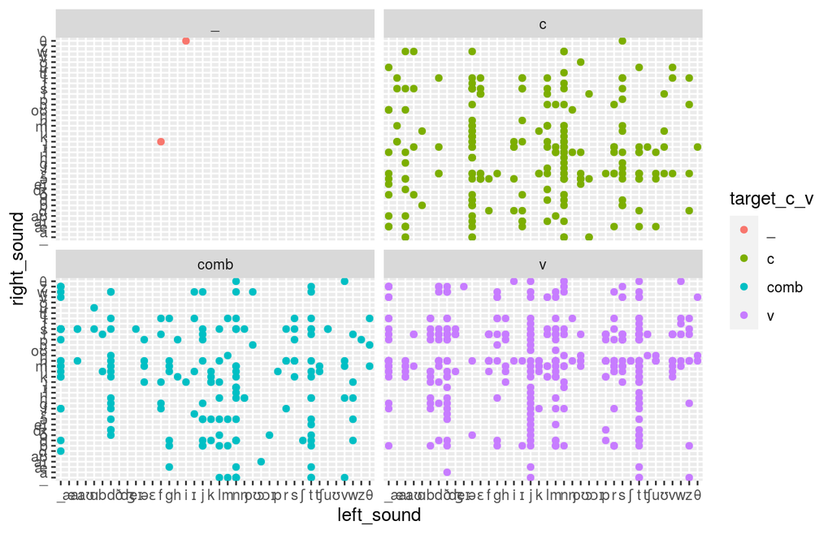

```r
ggplot(df, aes(x=left_sound, y = right_sound, color=target_c_v))+
  geom_point()+
  facet_wrap(~target_c_v)
```

Secondary stressed monophthongs present the minority of target vowels in our data.

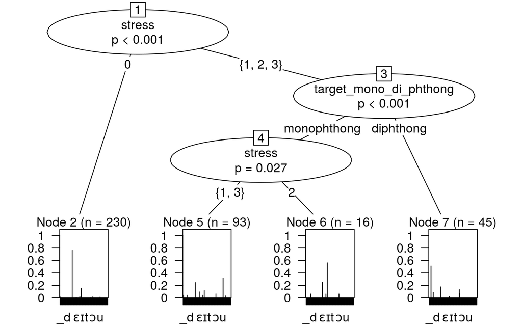

```r
vow <-subset(df, df$target_c_v == "v")
fit <- party::ctree(correct_target~target_mono_di_phthong+stress, data=vow)
plot(fit)
```

## Decision trees

Target vowels that are present in our dataset are largely monophthongs that bear no stress.

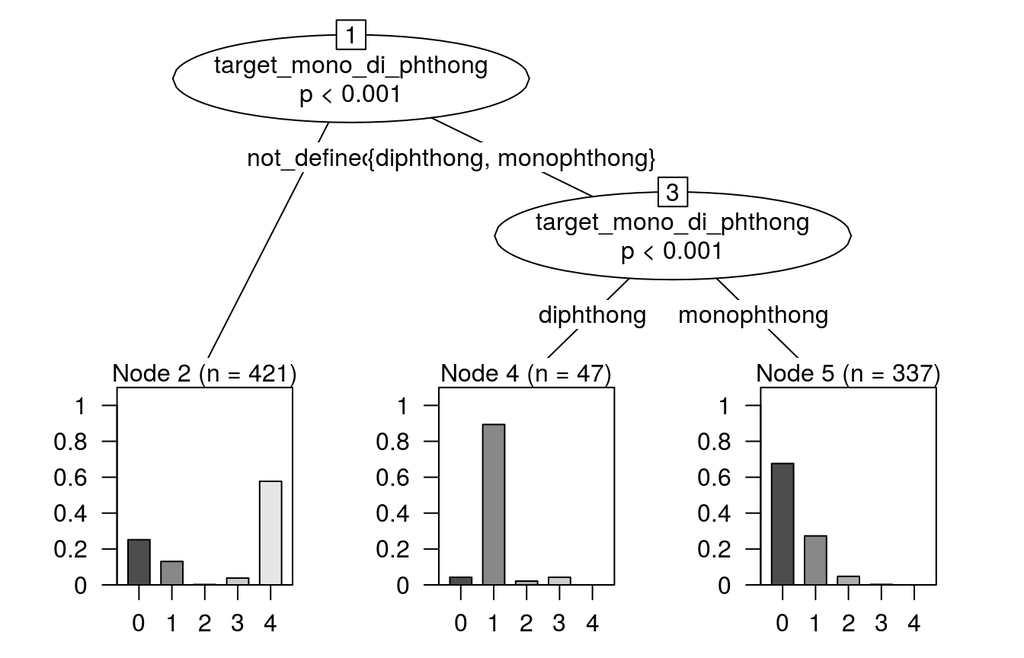

```r
#tr <-subset(df, df$target_c_v == "v")
fit <- party::ctree(stress~target_mono_di_phthong, data=df)
plot(fit)
```

Target consonants that are present in our dataset are both voiced and unvoiced.

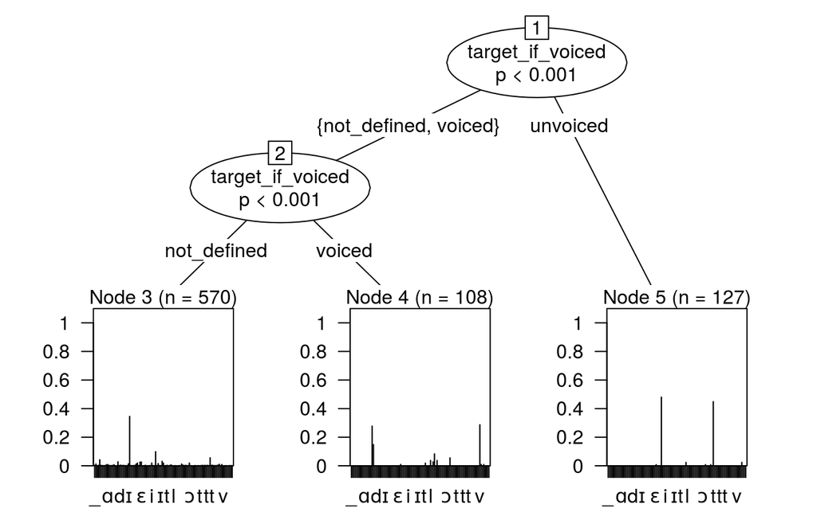

```r
fit <- party::ctree(correct_target~target_if_voiced, data=df)
plot(fit)
```

Distribution of stress types is similar for single vowels and combinations of sounds.

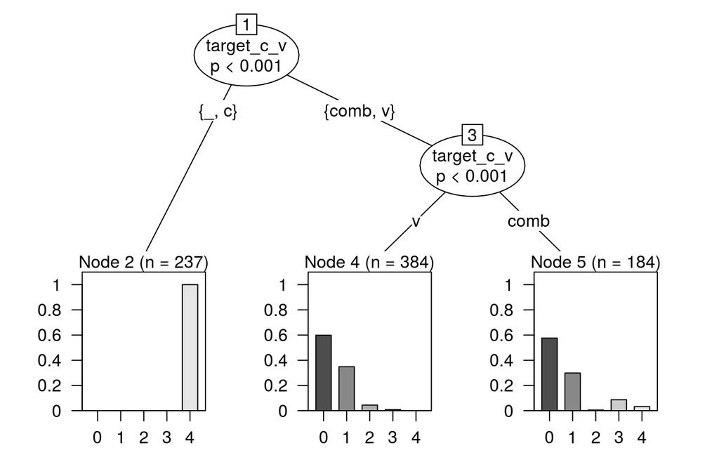

```r
fit <- party::ctree(stress~target_c_v+position, data=df)
plot(fit)
```

Most common case of elision in our dataset represents a vowel affected when followed by consonant.

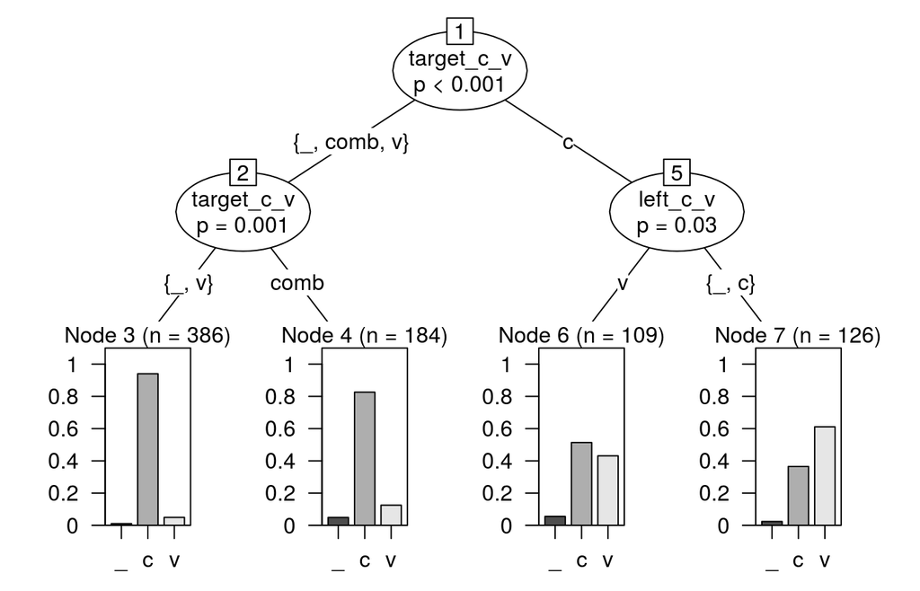

```r
tr <-subset(df, df$target_c_v == "v")
fit <- party::ctree(right_c_v~target_c_v+left_c_v, data=df)
plot(fit)
```

## Annotated data (file in repository in the .csv format, the paper contains a link to this file).

[link](https://raw.githubusercontent.com/lapythie/LingData_Project/master/final_dataset.csv)